# MA615 Midterm Project

Ziyan Li

October 24, 2016

```r
# read data
hms <- read.csv("HMS raw data 2016.csv")
```

# 1. Dataset Overview

This dataset is from MSSP consulting project, “Healthy Minds Study”, which focuses on BU student mental health and related issues. The dataset has 532 variables and 2551 observations, most of which are NAs. Since it is a survey data, there are different types of data. It is necessary to take a overview at the dataset.

```r
# write a function to help us recognize data type for each column
describe <- function(x){
  y = 0
  if (sum(is.na(x)) == length(x)) {
    y = "only NA"
  }
  else {
    x = na.omit(x)
    if (is.numeric(unique(x[2])) == FALSE){
      y = "text"
    }
    else{
      if (min(x) == 0 & max(x) == 1){
        y = "0 & 1"
      }
      else if (min(x) == 1 & max(x) == 1){
        y = "1 & NA"
      }
      else{
        if (max(x) < 10){
          y = "scale/categorical"
        }
        else{
          y = "numeric"
        }
      }
    }
  }
  return(y)
}
```

Apply the function to our dataset and return a statistics table.

```r
overview <- as.data.frame(sapply(hms, describe))
names(overview) <- "type"
kable(overview %>% group_by(type) %>% summarise(count=length(type)))
```

[output not shown]

# 2. Reorganize Data

```r
row.names(hms) <- hms$responseid
# absorb key words of column names
key <- paste("df",unlist(lapply(strsplit(names(hms), split="_"),function(x){x[1]})),sep = "_")
```

Create a function to help us split our dataset into separate data frames.

```r
pull <- function(x){   # input x is a single key word
  df = as.data.frame(hms[,grep(x,key)]) # search in column names
  colnames(df) = names(hms)[grep(x,key)]
  rownames(df) = rownames(hms)  # if not defined, single column section will lose row names
  assign(x, df, envir=.GlobalEnv) # save data frame to our global environment
}
```

Apply the function to our dataset.

```r
invisible(lapply(unique(key),pull))
# around 100 separate data frames will be created in global environment
```

Some adjustment will be needed.

```r
df_sex <- data.frame(df_gender, df_sex, df_relship)
df_socioeco <- data.frame(df_fincur, df_finpast, df_educ)
df_academic <- data.frame(df_degree, df_transfer, df_yr, df_enroll, df_field, df_gpa, df_aca, df_timeclass, df_timestud, df_persist)
df_depress <- data.frame(df_phq9, df_deprawsc, df_dep$dep_impa, df_phq2)
names(df_depress)[11] <- "dep_impa"
df_anxiety <- data.frame(df_gad7, df_anx$anx_score)
names(df_anxiety)[9] <- "anx_score"
df_eating <- data.frame(df_thin, df_body, df_height, df_weight, df_scoff, df_ed$ed_scoff)
names(df_eating)[11] <- "ed_scoff"
df_violence <- data.frame(df_violence, df_assault)
df_use <- data.frame(df_alc, df_binge, df_smok, df_drug)
df_help <- data.frame(df_med$med_help, df_ther$ther_help)
names(df_help) <- c("med_help", "ther_help")
df_stigma <- data.frame(df_stig$stig_pcv_1, df_stig$stig_per_1)
names(df_stigma) <- c("stig_pcv_1", "stig_per_1")
df_use_ct <- data.frame(df_ther$ther_any, df_ther$ther_vis, df_ther$ther_cur, df_prov)
names(df_use_ct)[1:3] <- c("ther_any", "ther_vis", "ther_cur")
df_satisf <- data.frame(df_sat, df_ther$ther_helped_me)
names(df_satisf)[length(df_satisf)] <- "ther_helped_me"
df_medic <- data.frame(df_meds, df_why)
df_informal <- data.frame(df_inf, df_talk2, df_talkaca, df_talksup)
df_know_mit <- data.frame(df_know$know_sp, df_dep[,3:10], df_anx[,2:5], df_ea, df_gk)
names(df_know_mit)[1] <- "know_sp"
df_know_cs <- data.frame(df_know$knowwher, df_outreach, df_heard, df_camp)
names(df_know_cs)[1] <- "knowwher"
df_belief <- data.frame(df_meds$meds_help_me, df_ther$ther_help_me)
names(df_belief) <- c("meds_help_me", "ther_help_me")
df_identity <- data.frame(df_self, df_dep$dep_secret, df_men)
names(df_identity)[2] <- "dep_secret"
df_stig_pcv <- data.frame(df_stig$stig_pcv_2, df_stig$stig_pcv_3, df_stig$stig_pcv_1)
names(df_stig_pcv) <- c("stig_pcv_2", "stig_pcv_3", "stig_pcv_1")
df_stig_per <- data.frame(df_stig$stig_per_2, df_stig$stig_per_3, df_stig$stig_per_1)
names(df_stig_per) <- c("stig_per_2", "stig_per_3", "stig_per_1")
df_belong <- data.frame(df_belong1, df_belong2, df_belong3, df_belong4, df_belong5, df_belong6, df_belong7, df_belong8, df_belong9)
df_camp_cli <- data.frame(df_mh, df_cli, df_st$st_promote, df_admin, df_env)
names(df_camp_cli)[4] <- "st_promote"
df_diverse <- data.frame(df_divers, df_discrim)
```

Finally, save our global environment as .RDa file.

```r
save.image("split_data.RData")
head(ls(), 20) # around 100 separate data.frames in total
```

```
##  [1] "describe"    "df_aca"      "df_academic" "df_activ"    "df_admin"
##  [6] "df_age"      "df_alc"      "df_anx"      "df_anxiety"  "df_anyprovi"
## [11] "df_assault"  "df_bar"      "df_belief"   "df_belong"   "df_belong1"
## [16] "df_belong2"  "df_belong3"  "df_belong4"  "df_belong5"  "df_belong6"
```

The output of reorganization is shown in the pdf file.

# 3. Clean Text Input

First of all, let’s take a overview of all the text columns.

```r
text <- as.data.frame(hms[,grep("text",colnames(hms))])
text[text==""] <- NA
colSums(!is.na(text))
```

```
##          gender_text          sexual_text         relship_text
##                   13                   45                   19
##      race_other_text relig_aff_other_text    degree_other_text
##                  132                  129                   67
##          enroll_text     field_other_text        residenc_text
##                   11                  404                   52
##     activ_other_text      disab_1_11_text       sib_other_text
##                   91                   39                   21
##     drug_other1_text     drug_other2_text     drug_other3_text
##                   20                    0                    0
##        dx_dep_5_text         dx_ax_9_text        dx_att_3_text
##                   20                   14                    6
##         dx_ea_4_text        dx_psy_7_text     dx_perso_11_text
##                   12                    0                    0
##         dx_sa_2_text         talk1_8_text          prov_9_text
##                    6                   27                   22
##          meds_7_text   meds_reason_5_text        meds_w_3_text
##                   27                   28                   21
##      meds_cur_7_text        why_tx_6_text        why_tx_8_text
##                   22                   45                    8
##        why_tx_9_text        bar_hs_7_text        bar_ns_8_text
##                   30                   56                   57
##           inf_7_text         talk2_7_text       ins_ina_8_text
##                   26                  114                   13
```

There are 36 text columns 4 of which are empty. According to our client’s demand, we firstly focus on clean the text input related to demographic variables. Here is an example our text cleaning workflow using 4 demographic variables.

#### (1) clean race text input

```r
# clean race
df_race$race_other_text[df_race$race_other_text==""] <- NA
colSums(!is.na(df_race)) # all colums related to race question.
```

```
##        race_his      race_white      race_black      race_asian
##            2464            1545             139             680
##     race_ainaan      race_mides         race_pi        race_haw
##              31              77              17               5
##      race_other race_other_text
##             141             132
```

```r
race_text <- unique(hms$race_other_text)
mixed <- c("Bi","bi","ix","and","-","part")
text_mixed <- race_text[grep(paste(mixed, collapse = "|"), race_text)]
asian <- c("sian","ndia","akist","nese")
text_asian <- race_text[grep(paste(asian, collapse = "|"), race_text)]
df_race$race[df_race$race_white == 1] <- "white"
df_race$race[df_race$race_black == 1] <- "black"
df_race$race[df_race$race_asian == 1 | df_race$race_other_text %in% text_asian] <- "asian"
df_race$race[rowSums(df_race[2:8], na.rm = TRUE) >1 | df_race$race_other_text %in% text_mixed] <- "mixed"
df_race$race[rowSums(!is.na(df_race[2:10])) >0 & is.na(df_race$race)] <- "other"
# out put: a single variable containing race information
kable(df_race %>% group_by(race) %>% summarise(count=length(race)))
```

| race | count |
| --- | --- |
| asian | 647 |
| black | 104 |
| mixed | 144 |
| other | 124 |
| white | 1438 |
| NA | 94 |

### (2) clean degree text input

```r
# clean degree
df_degree$degree_other_text[df_degree$degree_other_text==""] <- NA
colSums(!is.na(df_degree))
```

```
##       degree_bach         degree_ma         degree_jd         degree_md
##              1310               703                64                77
##        degree_phd      degree_other degree_other_text        degree_ass
##               257                68                67                36
```

```r
unique(df_degree$degree_other_text[rowSums(is.na(df_degree[,2:6]))==5])
```

```
## [1] <NA>
## 31 Levels:  Advanced standing DMD 2 year program As AT/DPT BA/MA ... Performance diploma
```

```r
df_degree$degree[rowSums(!is.na(df_degree)) >0] <- "graduate"
df_degree$degree[df_degree$degree_bach==1] <- "undergraduate"
df_degree$degree[rowSums(df_degree[,2:5], na.rm = TRUE) >0] <- "graduate" # record the highest possible degree
kable(df_degree %>% group_by(degree) %>% summarise(count=length(degree)))
```

| degree | count |
| --- | --- |
| graduate | 1167 |
| undergraduate | 1277 |
| NA | 107 |

### (3) clean gender text input

```r
# clean gender
# for gender we can simply ignore text input since our client asked to recode gender into four categories.
df_gender$gender1[df_gender$gender == 1] <- "male"
df_gender$gender1[df_gender$gender == 2] <- "female"
df_gender$gender1[df_gender$gender == 3 | df_gender$gender == 4] <- "trans"
df_gender$gender1[df_gender$gender == 5 | df_gender$gender == 6] <- "other"
kable(df_gender %>% group_by(gender1) %>% summarise(count=length(gender1)))
```

| gender1 | count |
| --- | --- |
| female | 1679 |
| male | 774 |
| other | 27 |
| trans | 5 |
| NA | 66 |

### (4) clean citizen text input

```r
# clean citizen
df_citizen$citizen1[df_citizen$citizen == 1] <- "domestic"
df_citizen$citizen1[df_citizen$citizen == 0] <- "international"
kable(df_citizen %>% group_by(citizen1) %>% summarise(count=length(citizen1)))
```

| citizen1 | count |
| --- | --- |
| domestic | 1957 |
| international | 511 |
| NA | 83 |

#### combine these four new columns into a new data.frame

```r
# combine demographic
df_demo <- data.frame(gender=df_gender$gender1, race=df_race$race, citizen=df_citizen$citizen1, degree=df_degree$degree)
```

# 4. Plot Data

Since most of the efforts are put into cleaning process, the visualization part will be a little plain.

```r
par(mfrow=c(2,2))
demo1 <- table(df_demo$race, df_demo$degree)
demo1
```

```
##
##         graduate undergraduate
##   asian      306           332
##   black       43            59
##   mixed       46            97
##   other       70            54
##   white      696           725
```

```r
demo2 <- table(df_demo$gender, df_demo$degree)
demo2
```

```
##
##          graduate undergraduate
##   female      760           895
##   male        394           363
##   other        11            15
##   trans         1             4
```

```r
demo3 <- table(df_demo$degree, df_demo$citizen)
demo3
```

```
##
##                 domestic international
##   graduate           866           298
##   undergraduate     1068           207
```

```r
demo4 <- table(df_demo$race, df_demo$citizen)
demo4
```

```
##
##         domestic international
##   asian      295           351
##   black       97             7
##   mixed      139             5
##   other       73            51
##   white     1339            95
```

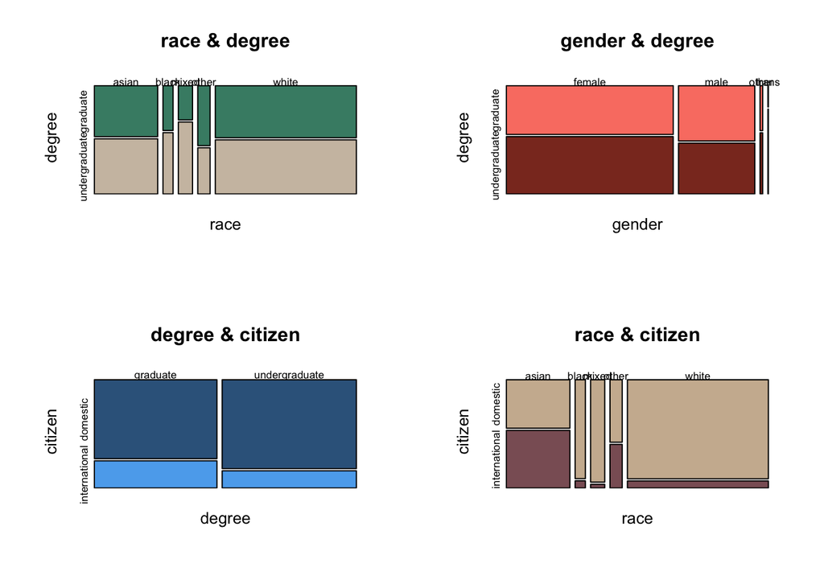

```r
mosaicplot(demo1, color = c("aquamarine4","antiquewhite3"), main="race & degree", xlab="race", ylab="degree")
mosaicplot(demo2, color = c("salmon","tomato4"), main="gender & degree", xlab="gender", ylab="degree")
mosaicplot(demo3, color = c("steelblue4","steelblue2"), main="degree & citizen", xlab="degree", ylab="citizen")
mosaicplot(demo4, color = c("bisque3","lightpink4"), main="race & citizen", xlab="race", ylab="citizen")
```